# ACTF Nightlife Data Analysis and Outputs

Michael Fichman

April 8, 2022

# About

Analysis by Michael Fichman of Philadelphia City Council’s Arts and Culture Task Force, Nightlife Committee of wage tax revenue data obtained from Philadelphia Controller’s Office, updated for the 2021 tax year, 3/8/2022.

For code base used to synthesize these data, refer to the code download button at the top of this document or visit the github repository for this page - https://github.com/mafichman/ACTF_nightlife

Questions, contact mfichman@upenn.edu

# Wage Tax Receipts

Quarterly wage tax receipts for industries in the arts and hospitality were dramatically impacted by the pandemic which began in March, 2020, and have not fully recovered.

Data on nighttime-specific industries tend not to be subdivided by day and nighttime activity in wage tax data.

All dollar values adjusted for inflation (2021 dollars) based on BLS guidelines.

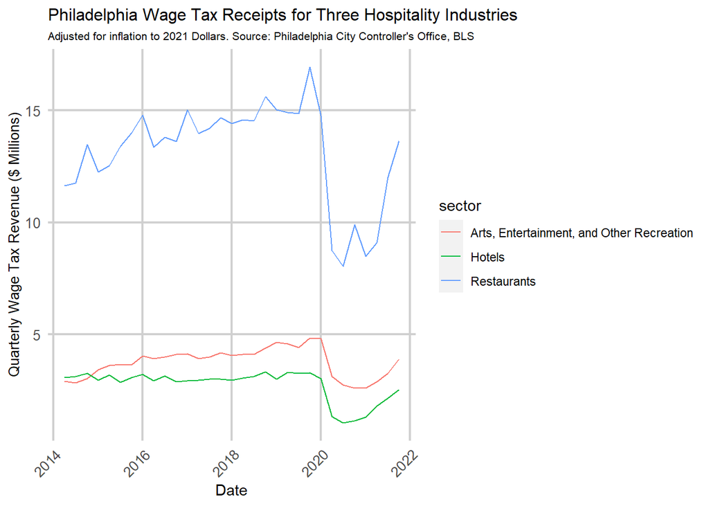

Tax revenues by year in millions of dollars

| year | Arts, Entertainment, and Other Recreation | Hotels | Restaurants |
| --- | --- | --- | --- |
| 2014 | 8.78 | 9.47 | 36.89 |
| 2015 | 14.35 | 12.10 | 52.20 |
| 2016 | 16.06 | 12.18 | 55.62 |
| 2017 | 16.21 | 11.87 | 57.90 |
| 2018 | 16.65 | 12.44 | 59.19 |
| 2019 | 18.48 | 12.83 | 61.75 |
| 2020 | 13.26 | 6.53 | 41.47 |
| 2021 | 12.63 | 7.81 | 43.26 |

# Changes In Tax Revenue in Pandemic Year 1

As gross (in millions of US dollars, adjust for inflation to 2021 dollars) and as a percentage change.

| variable | Pre-pandemic year | Pandemic year 1 | Pct_Change |
| --- | --- | --- | --- |
| Arts_Entertainment_Recreation | 16.51 | 10.81 | -34.52 |
| Hotels | 11.55 | 4.75 | -58.87 |
| Restaurants | 55.84 | 33.08 | -40.76 |
| Total | 1964.94 | 1787.38 | -9.04 |

# Loss Estimates and Recovery Timeline

Tax revenues by the end of 2021 are still falling short of expected, meaning that recovery has not been achieved. Expected revenues are based on 2014-2020(TY Q1) trends (based on year, quarter and sector) and adjusted for inflation to 2021 dollars.

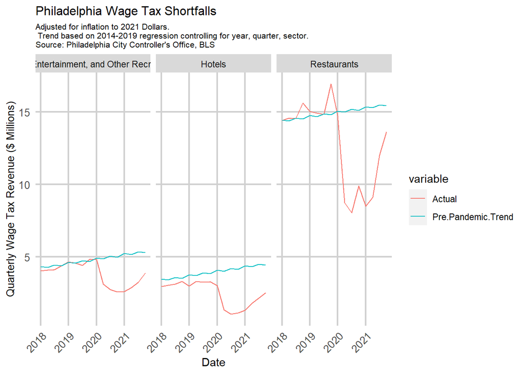

Wage tax losses since the beginning of 2020, relative to projections based on 2014-19, are still as much as $2 million per quarter by sector.

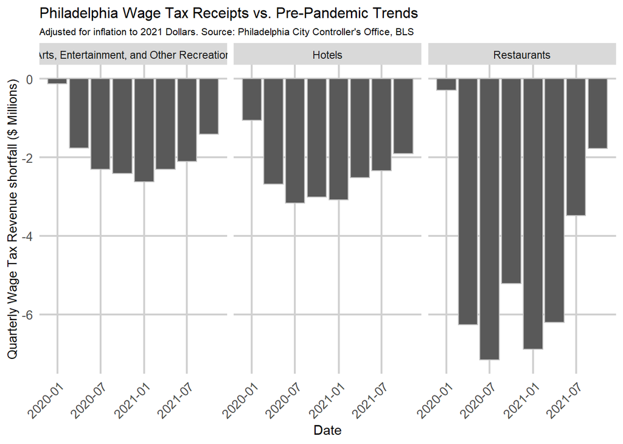

Total tax shortfalls (compared to pre-pandemic trend) since March, 2020, in millions (2021 dollars)

| sector | Est Loss (millions) |
| --- | --- |
| Arts, Entertainment, and Other Recreation | -14.91 |
| Hotels | -18.69 |
| Restaurants | -36.96 |

# Save Our Stages Grants

This repo contains interactive maps and analysis of SBA Grants given as part of the “Save Our Stages” Act passed by the US Congress.

The data being used here have been geocoded using the Google Geocoding service, which is highly accurate but not error free. Data are current as of August 17, 2021, and are available [from the SBA](https://data.sba.gov/dataset/svog/resource/33270c2a-f1c5-4dcb-bc98-aedcaec19ef3).

The following map shows the grantee locations.

[interactive chart not shown]